# NHANES Weartime Vignette

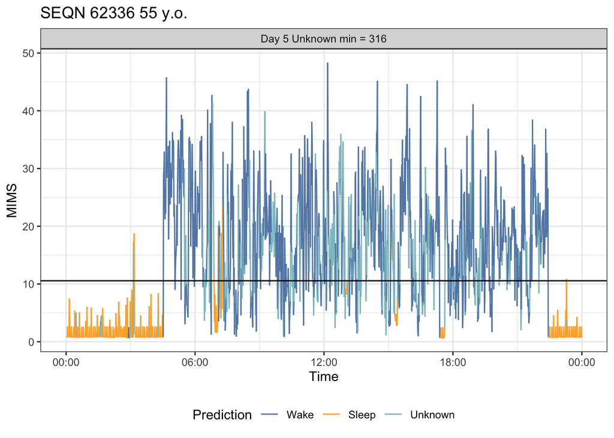

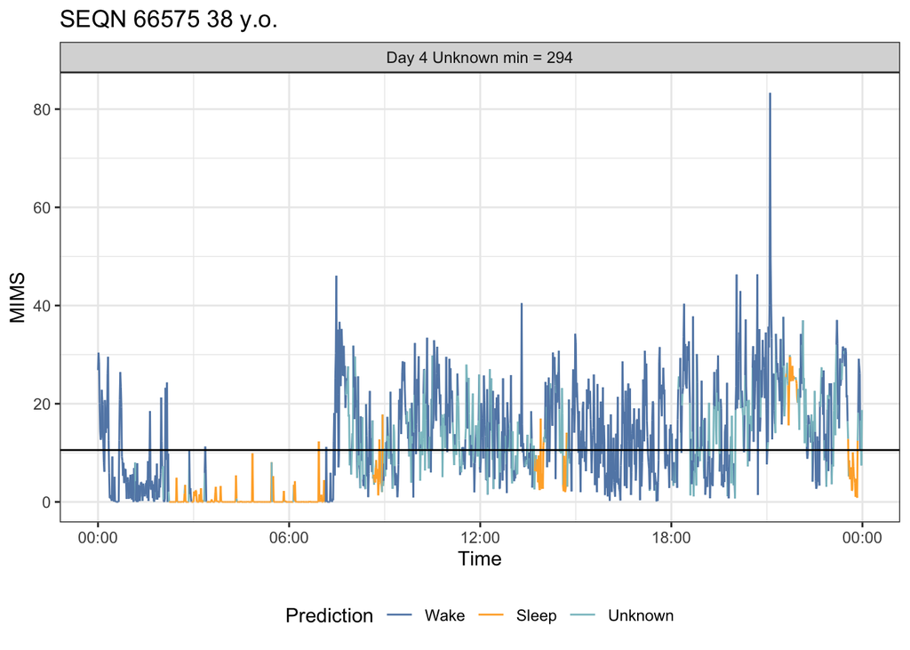

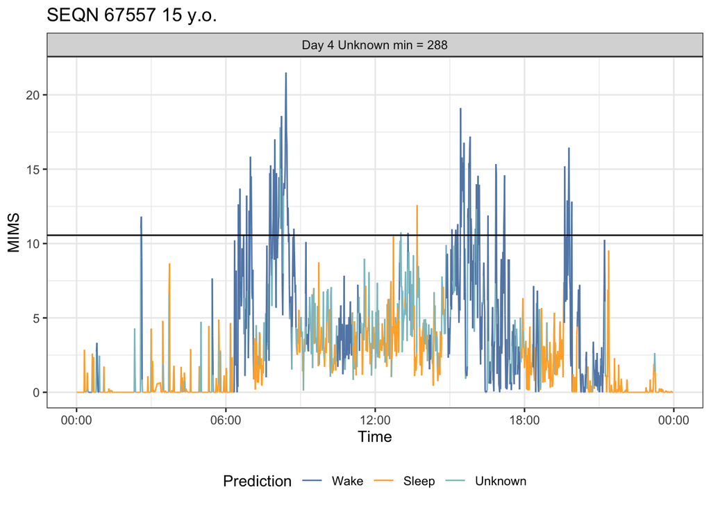

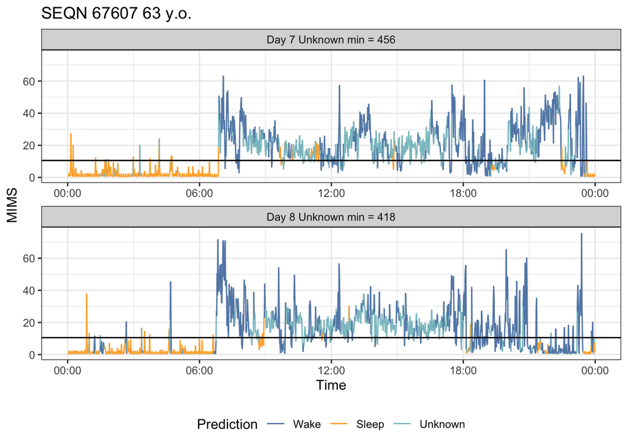

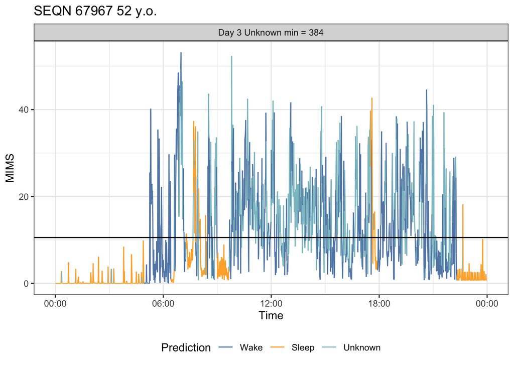

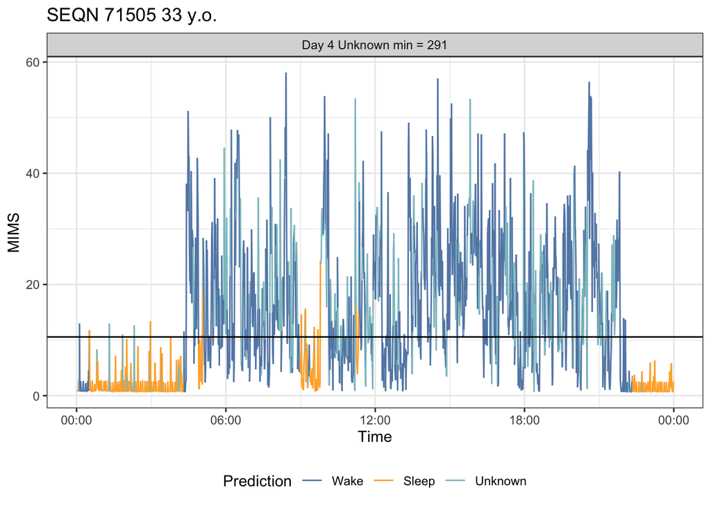

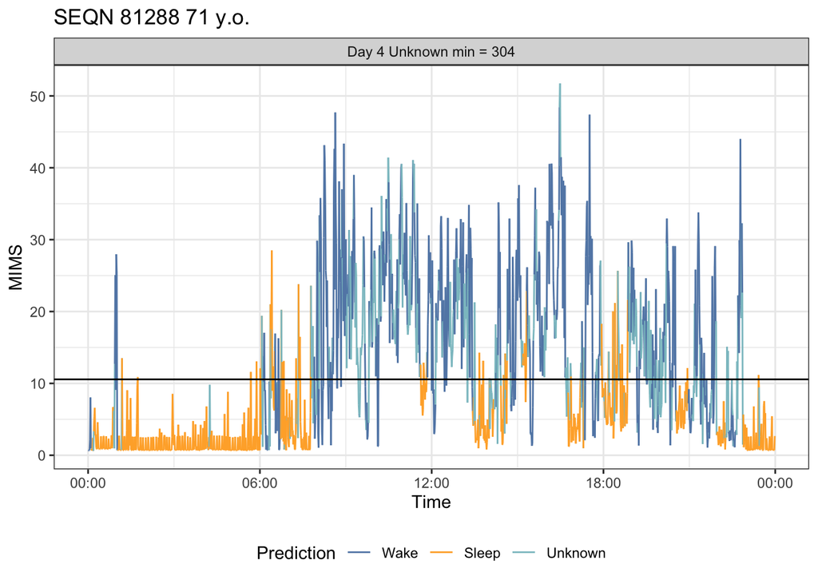

```r
ids = unique(all_min_files_joined %>%
          filter(type == "unknown") %>%
          pull(SEQN))
for(subject in 1:length(ids)){
  subj = ids[subject]
  age = all_min_files_joined %>%
    filter(SEQN == subj) %>%
    slice(1) %>%
    pull(age_in_years_at_screening)
  p =
    all_min_files_joined %>%
    filter(SEQN == subj) %>%
    mutate(pred = factor(
      case_when(
        PAXPREDM == 1 ~ "Wake",
        PAXPREDM == 2 ~ "Sleep",
        PAXPREDM == 3 ~ "Nonwear",
        PAXPREDM == 4 ~ "Unknown"
      ),
      levels = c("Wake", "Sleep", "Nonwear", "Unknown")),
      minutes = paste0("Day ", PAXDAYM, " Unknown min = ", WTPRED_4)) %>%
    ggplot(aes(
      x = time,
      y = PAXMTSM,
      col = pred,
      group = 1
    )) +
    geom_line() +
    facet_wrap(. ~ minutes, scales = "free_x", nrow = 3) +
    labs(x = "Time", y = "MIMS", title = paste0("SEQN ", subj, " ", age, " y.o.")) +
    theme_bw() +
    scale_x_datetime(labels = date_format("%H:%M")) +
    theme(legend.position = "bottom") +
    scale_color_manual(
      name = "Prediction",
      values = c(
        "Wake" = "#6388B4FF",
        "Sleep" = "#FFAE34FF",
        "Nonwear" = "#EF6F6AFF",
        "Unknown" = "#8CC2CAFF"
      )
    )+
    geom_hline(yintercept = 10.558)
  print(p)
}
```

# Patterns of wake, sleep wear by age

Finally, we can look at patterns of sleep and wake wear by age.

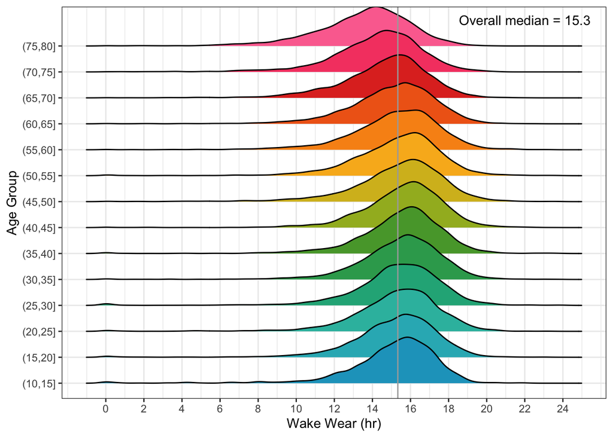

```r
median =
  all_1368 %>%
  filter(age_in_years_at_screening >= 15) %>%
  summarize(median = median(WTPRED_1)) %>%
  pull(median)

plt =
  all_1368 %>%
  filter(age_in_years_at_screening >= 15) %>%
  mutate(age_group = cut(age_in_years_at_screening, breaks=seq(0,85, 5), include.lowest = TRUE)) %>%
  ggplot(aes(x = WTPRED_1, y = age_group, fill = age_group))+
  geom_density_ridges()+
  theme_bw() +
  scale_fill_paletteer_d("ggthemes::Hue_Circle")+
  theme(legend.position = "none")+
  scale_x_continuous(breaks=seq(0, 1440, 120),
                     labels = seq(0, 24, 2))+
  labs(x = "Wake Wear (hr)", y = "Age Group")+
  geom_vline(xintercept = median, col = "darkgrey")

plt +
  annotate("text", x = 22*60, y = 15, label = paste0("Overall median = ", round(median / 60, 1)))
```

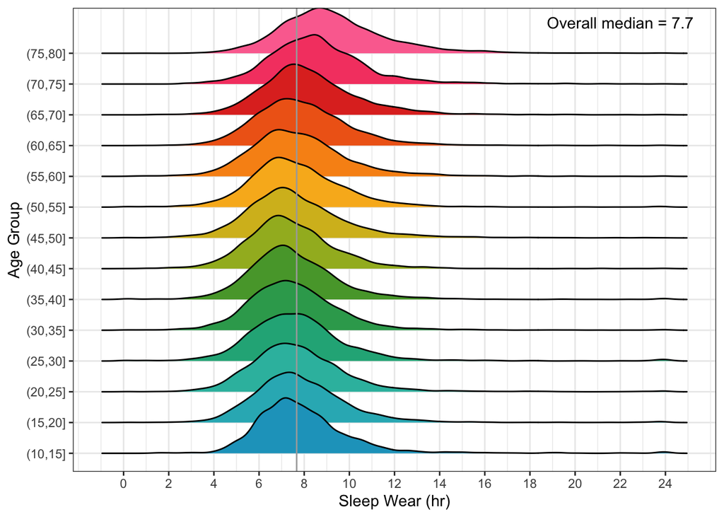

```r
  # geom_text(aes(x = 22 * 60, y = 15, label = median))


median =
  all_1368 %>%
  filter(age_in_years_at_screening >= 15) %>%
  summarize(median = median(WTPRED_2)) %>%
  pull(median)

all_1368 %>%
  filter(age_in_years_at_screening >= 15) %>%
  mutate(age_group = cut(age_in_years_at_screening, breaks=seq(0,85, 5), include.lowest = TRUE)) %>%
  ggplot(aes(x = WTPRED_2, y = age_group, fill = age_group))+
  geom_density_ridges()+
  theme_bw() +
  scale_fill_paletteer_d("ggthemes::Hue_Circle")+
  theme(legend.position = "none")+
  scale_x_continuous(breaks=seq(0, 1440, 120),
                     labels = seq(0, 24, 2))+
  labs(x = "Sleep Wear (hr)", y = "Age Group")+
  geom_vline(xintercept = median, col = "darkgrey")+
  annotate("text", x = 22*60, y = 15, label = paste0("Overall median = ", round(median / 60, 1)))
```

# Final criteria

Based on the above visualizations, we think the following criteria is reasonable for a day to be considered valid:

- At least 1368 minutes (95% of a full day) of wake, sleep, or unknown
- At least 7 hours (420 minutes) of wake wear
- > 0 total MIMS

We can look at the distribution of valid days per individual, based on this criteria.

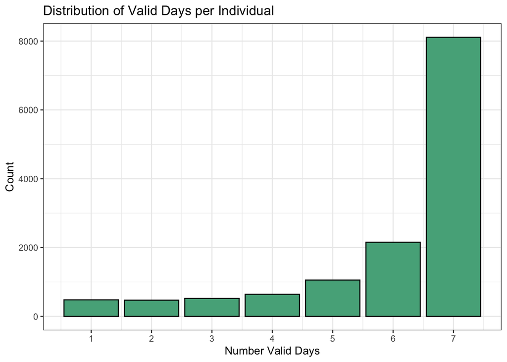

```r
all_days_valid =
  all_days %>%
  filter(WTPRED_1 + WTPRED_2 + WTPRED_4 >= 1368) %>%
  filter(WTPRED_1 >= 7 * 60) %>%
  filter(MIMS_weartotal > 0)

all_days_valid %>%
  group_by(SEQN) %>%
  count() %>%
  ggplot(aes(x= n))+
  geom_bar(stat = "count", col = "black", fill = "#55AD89FF")+
  theme_bw() +
  labs(x = "Number Valid Days", y = "Count", title = "Distribution of Valid Days per Individual")+
  scale_x_continuous(breaks=seq(1, 7, 1))
```

We can also plot the number of valid days per individual and mean daily MIMS. There odesn’t appear to be a relationship between valid days and mean MIMS, which is reassuring.

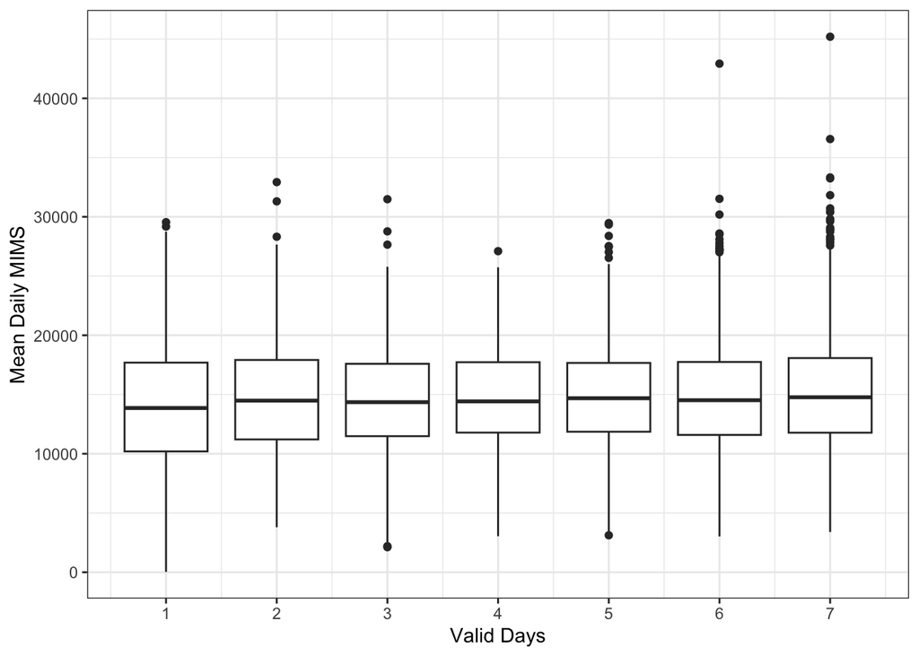

```r
all_days_valid %>%
  group_by(SEQN) %>%
  mutate(valid_days = n()) %>%
  group_by(SEQN, gender, age_in_years_at_screening, valid_days) %>%
  summarize(across(c(MIMS_weartotal, WTPRED_1, WTPRED_2),
                   ~mean(.x))) %>%
  ggplot(aes(x = valid_days, y = MIMS_weartotal, group = valid_days))+
  geom_boxplot()+
  theme_bw()+
  scale_x_continuous(breaks=seq(1, 7, 1))+
  labs(x = "Valid Days", y = "Mean Daily MIMS")
```

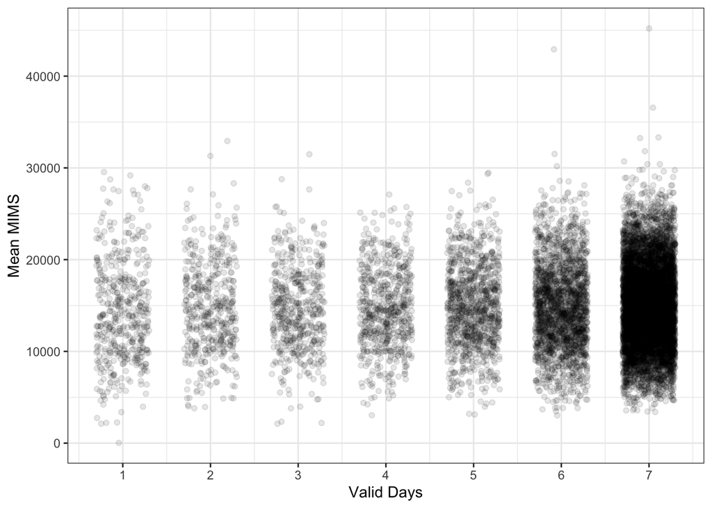

```r
all_days_valid %>%
  group_by(SEQN) %>%
  mutate(valid_days = n()) %>%
  group_by(SEQN, gender, age_in_years_at_screening, valid_days) %>%
  summarize(across(c(MIMS_weartotal, WTPRED_1, WTPRED_2),
                   ~mean(.x))) %>%
  ggplot(aes(x = valid_days, y = MIMS_weartotal))+
  geom_jitter(width = .3, alpha = .1)+
  theme_bw()+
  scale_x_continuous(breaks=seq(1, 7, 1))+
  labs(x = "Valid Days", y = "Mean MIMS")
```

## Footnotes

[^1]: https://pubmed.ncbi.nlm.nih.gov/22936409/, https://pubmed.ncbi.nlm.nih.gov/23036822/
[^2]: https://www.ncbi.nlm.nih.gov/pmc/articles/PMC9615811/
[^3]: https://www.ncbi.nlm.nih.gov/pmc/articles/PMC8277083/
[^4]: https://www.ncbi.nlm.nih.gov/pmc/articles/PMC7012355/
[^5]: https://pubmed.ncbi.nlm.nih.gov/34308270/
[^6]: https://www.ncbi.nlm.nih.gov/pmc/articles/PMC9356340/